# MTH6139 Time Series

Coursework 1

Pheneas Newman

March 2024

# 1 Introduction

This project is an analysis of the number of monthly air passengers from 1949 - 1960. I will also attempt to predict future air passengers with two different methods, Holt-Winters and the Meta Prophet system. I will also compare and contrast the two prediction methods

# 2 Linear Regression

This section is a brief analysis of the AirPassengers data in the form of a linear regression model and a prediction using the Holt-Winters method

### 2.1 Setup

We start by loading the `AirPassengers` data set and then converting this into a time series using the `ts(AirPassengers)` function.

Next we create a linear regression model by using the `lm` function and I have provided a summary of the model below.

```r
summary(LinearModel)
```

```
##
## Call:
## lm(formula = passengers_ts ~ time(passengers_ts))
##
## Residuals:
##     Min      1Q  Median      3Q     Max
## -93.858 -30.727  -5.757  24.489 164.999
##
## Coefficients:
##                       Estimate Std. Error t value Pr(>|t|)
## (Intercept)         -62055.907   2166.077  -28.65   <2e-16 ***
## time(passengers_ts)     31.886      1.108   28.78   <2e-16 ***
## ---
## Signif. codes:  0 '***' 0.001 '**' 0.01 '*' 0.05 '.' 0.1 ' ' 1
##
## Residual standard error: 46.06 on 142 degrees of freedom
## Multiple R-squared:  0.8536, Adjusted R-squared:  0.8526
## F-statistic: 828.2 on 1 and 142 DF,  p-value: < 2.2e-16
```

This shows a multiple R-squared value of `0.8536` suggesting a strong positive relationship between time progressing and the number of air passengers increasing. Likely a result of flight becoming more accessible, cheaper, and more people having access to passports.

### 2.2 Plotting the data and the regression line

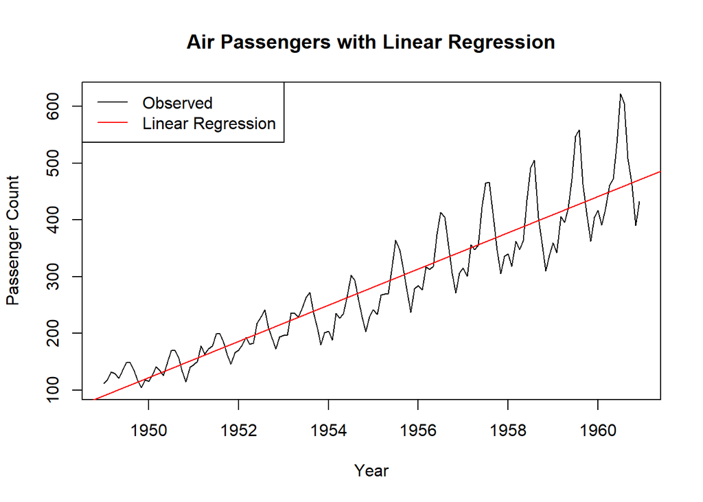

Just from looking at the plot it is clear that overtime there are more passengers, we can also see that the variability in the number of fliers each year is increasing. There is also clearly a seasonality component as there are consistent highs and lows of number of fliers, likely corresponding to summer holidays and people being home for Christmas, further analysis of this will be conducted in the time series decomposition section.

To investigate the variance increasing we will analyse the standardised residuals to see if they are normally distributed or follow a pattern.

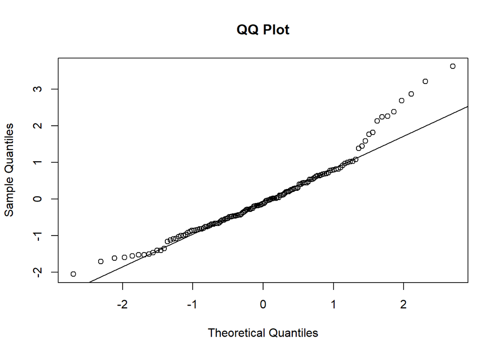

This graph is to see how closely the residuals follow a normal distribution. We would expect for a data set with consistent variance to have nearly all data points on the line. Here we can see that towards the right hand side of the graph the points are very far away from the line. This suggests that the larger values in the data set (later years) have a greater variance. This is investigated further by conducting a Shapiro-Wilkes test for normality, using the `shapiro.test()` function

```
##
##  Shapiro-Wilk normality test
##
## data:  StandardisedResiduals
## W = 0.94791, p-value = 3.207e-05
```

This outputs a p-value of `3.207e-05` which is very small. A small p-value here means that the standardised residuals do not follow a normal distribution. This is statistical evidence that the variability is increasing. An increasing variability over time will make predicting future data much more challenging, and potentially less accurate. A linear regression model may not be particularly suitable for this task

### 2.3 Holt-Winters Prediction

Here I forecast an additional two years of data by using the Holt-Winters forecasting method and the `forecast` library included in RStudio. The key function is `HoltWinters` to generate the model and then I add the predicted data to the original time series plot.

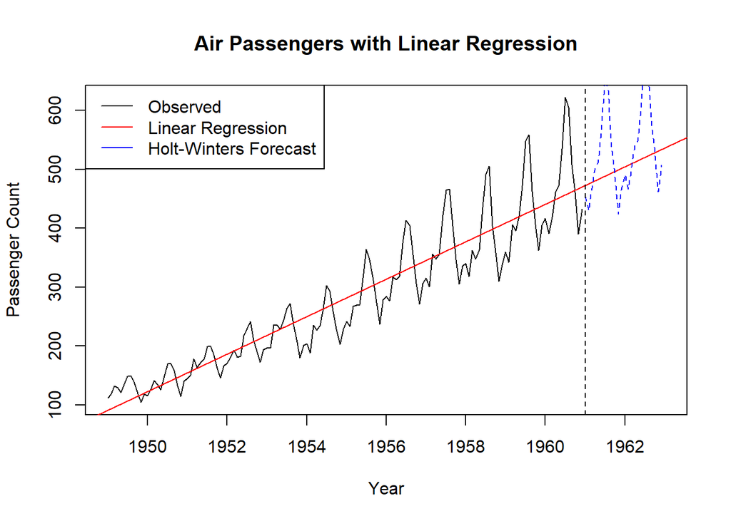

# 3 Time Series Decomposition

This section features a time series decomposition to analyse the seasonality, trend, and randomness of the data. This is mainly to make sure the seasonality component remains consistent over the years as this would impact the Meta Prophet prediction.

### 3.1 Decomposition

We start by using the `decompose` function on the `AirPassengers` data that is already in the form of a time series.

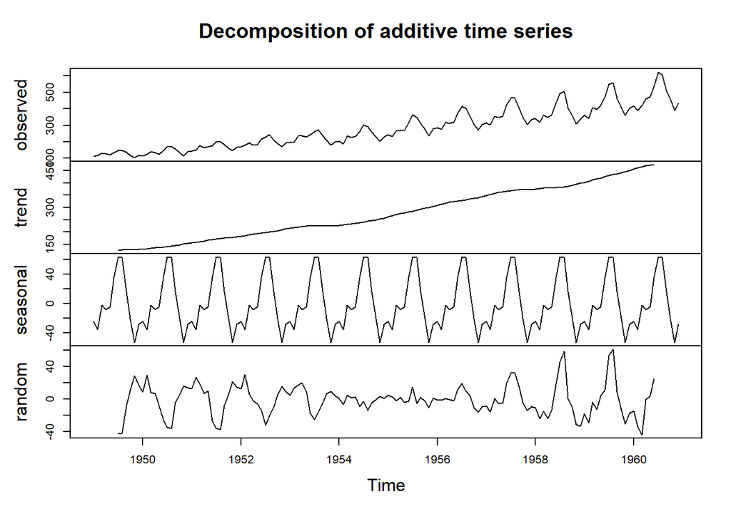

The trend plot clearly shows that the number of monthly air passengers is on the rise. The seasonality also suggests that there is a pattern to the number of fliers in each month.Here we will analyse the seasonality of the data.

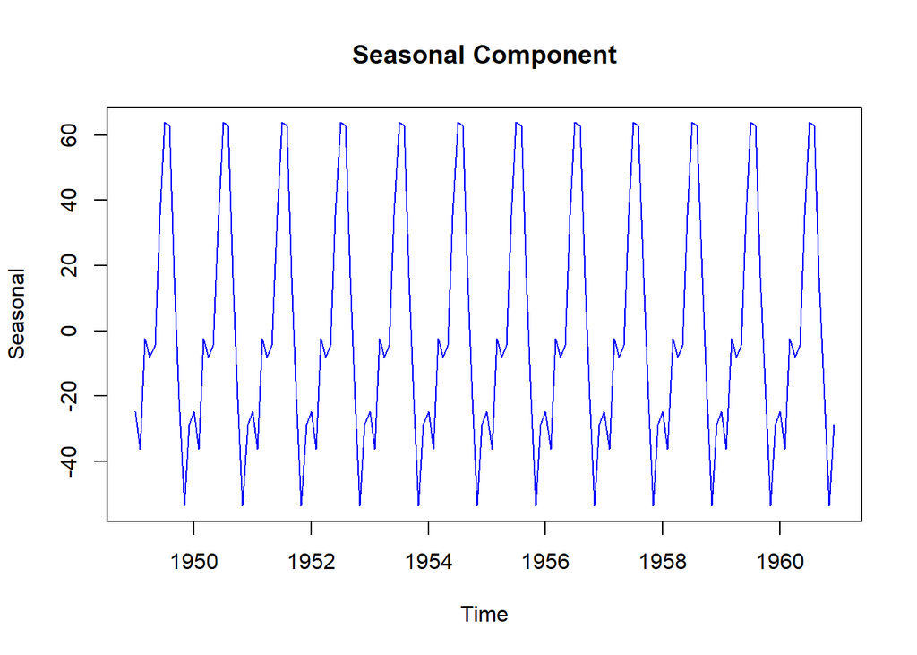

This graph clearly shows that there is a seasonal pattern for the number of passengers flying in each of the months.

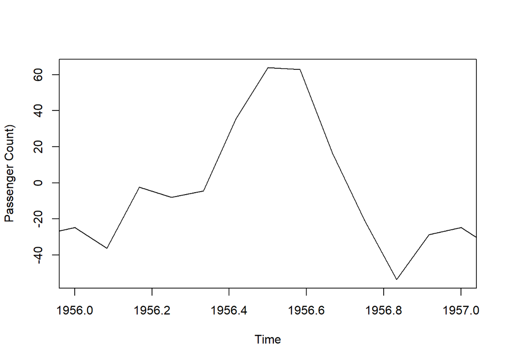

# 4 Meta Prophet Prediction

### 4.1 Introduction

This section is where the `prophet` library is used. Again I will predict two years of data, but using this method instead.

### 4.2 Prediction

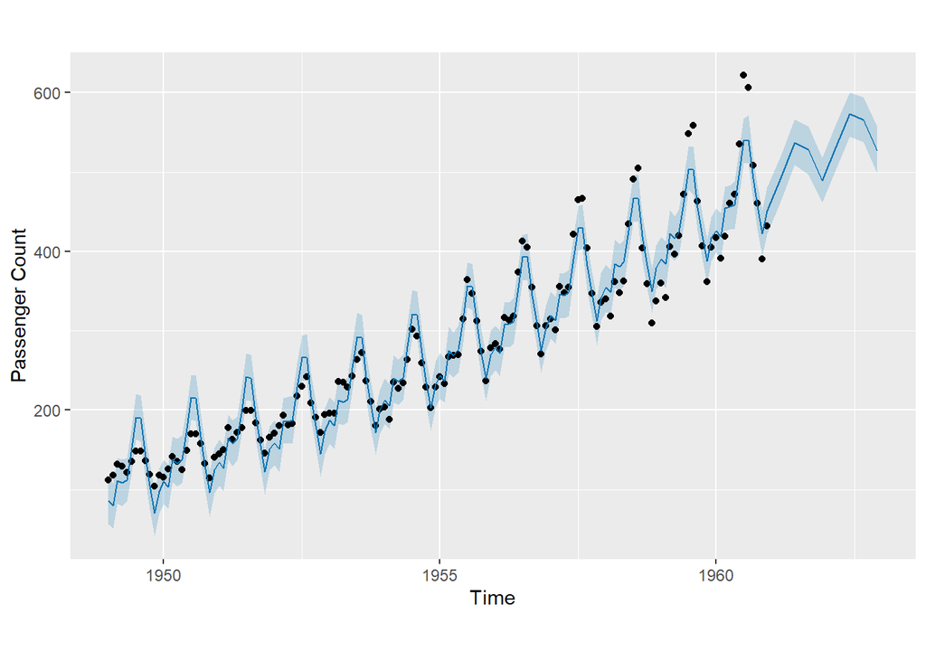

We can see from this plot that the Meta prediction seems to be underestimating the data compared the Holt-Winters method. This plot has the first year of predicted data having a seasonal peak lower than the previous year which goes against the original data and what we would expect to see.